# R for Data Science (IV)

### 24.2.1 Price and carat

It looks like lower quality diamonds have higher prices because there is an important confounding variable: the weight(`carat`) of the diamond. The weight of the diamond. The weight of the diamond is the single most important factor for determining thde price of the diamond, and lower quality diamonds tend to be larger.

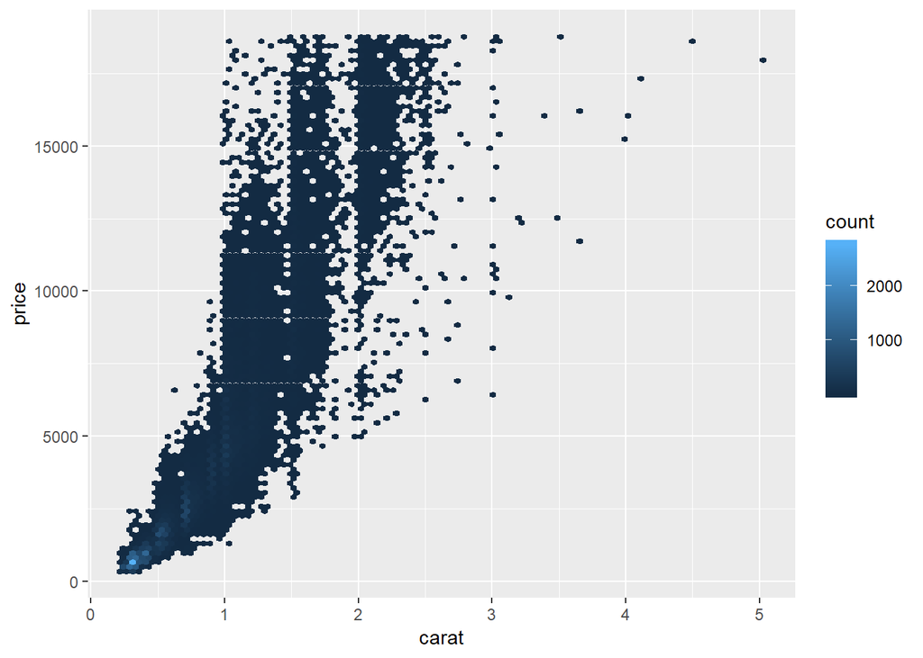

```r
ggplot(diamonds,aes(carat,price))+
  geom_hex(bins=100)
```

We can make it easier to see how the other attributes of a diamond affect its relative `price` by fitting a model to separate out the effect of carat. But first, lets make a couple of tweaks to the diamonds dataset to make it easier to work with:

1. Focus on diamonds smaller than 2.5 carat(99.7% of the data)

```r
# data count
n <- diamonds %>%
  ungroup() %>%
  count()

n_1 <- diamonds %>%
  filter(carat<=2.5) %>%
  count()
n_1/n
```

```
##           n
## 1 0.9976641
```

2. Log-transform the carat and price variables

```r
diamonds2 <- diamonds %>%
  filter(carat<=2.5) %>%
  mutate(lprice=log2(price),
         lcarat=log2(carat))
```

Together, these changes make it easier to see the relationship between `carat` and `price`.

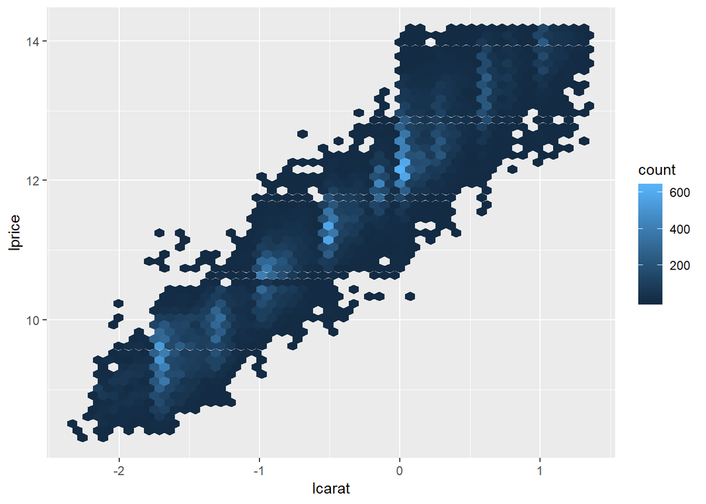

```r
ggplot(diamonds2, aes(lcarat,lprice))+
  geom_hex(bins=50)
```

The log-transformation is particularly useful here because it makes the pattern linear, and linear patterns are the easiest to work with. Let’s take the next step and remove that strong linear pattern. We first make the pattern explicit by fitting a model:

```r
mod_diamonds <- lm(lprice~lcarat,data=diamonds2)
```

Then, we look at what the model tells us about the data. Note that I back transform the predictions, undoing the log transformation, so I can overlay the predictions on the raw data:

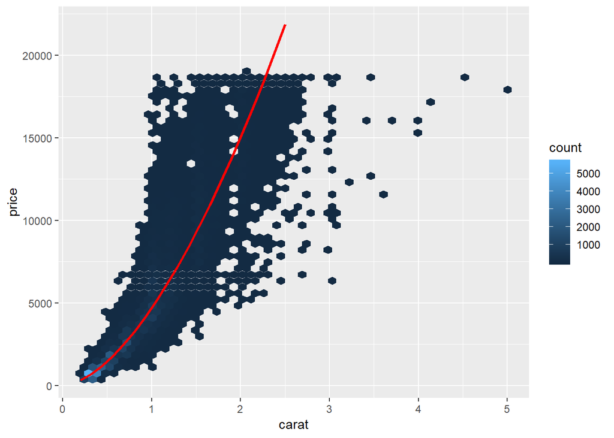

```r
grid <- diamonds2 %>%
  data_grid(carat=seq_range(carat,20)) %>%
  mutate(lcarat=log2(carat)) %>%
  add_predictions(mod_diamonds,"lprice") %>%
  mutate(price=2^lprice)

ggplot(diamonds,aes(carat,price))+
  geom_hex(bins=50)+
  geom_line(data=grid,colour="red",size=1)
```

That tells us something interesting about our data. If we believe our model, then the large diamonds are much cheaper than expected. This is probably because no diamond in this dataset costs more than $19,000.

Now we can look at the residuals, which verifies that we have successfully removed the strong linear pattern:

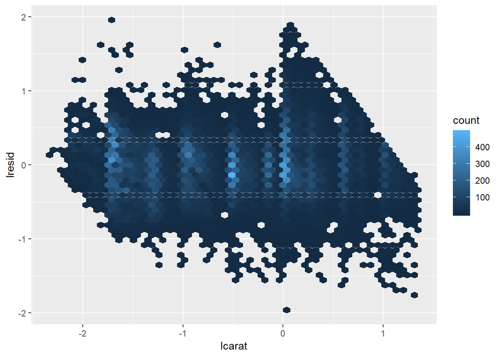

```r
diamonds2 <- diamonds2 %>%
  add_residuals(mod_diamonds,"lresid")

ggplot(diamonds2,aes(lcarat,lresid))+
  geom_hex(bins=50)
```

Impoortantly, we can now re-do motivating plots using those residuals instead of `price`.

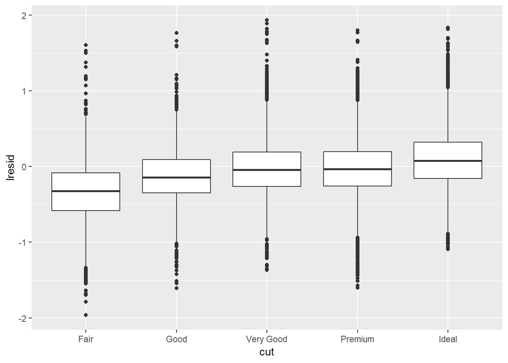

```r
ggplot(diamonds2, aes(cut,lresid))+geom_boxplot()
```

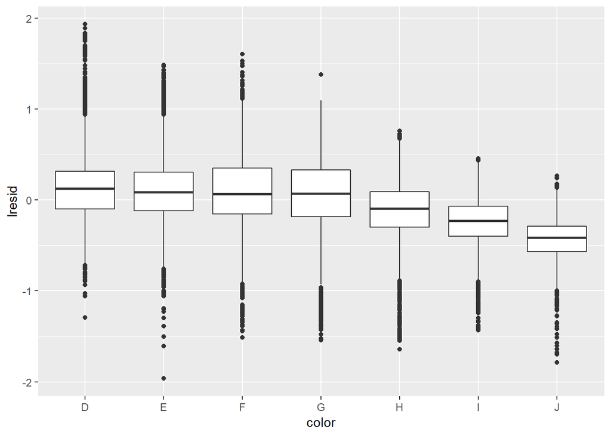

```r
ggplot(diamonds2, aes(color,lresid))+geom_boxplot()
```

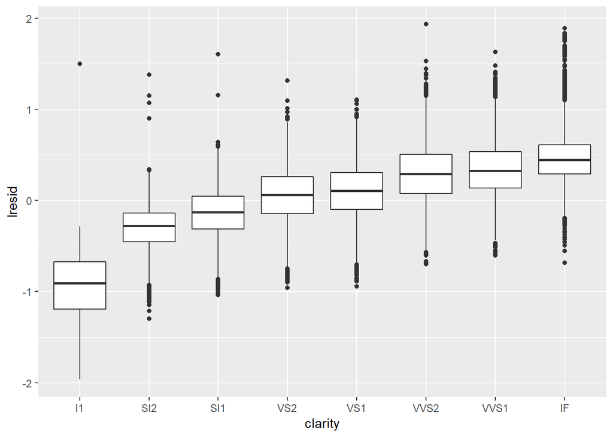

```r
ggplot(diamonds2, aes(clarity,lresid))+geom_boxplot()
```

Now we see the relationship we expect: as the quality of the diamond increases, so too does its relative price. To interpret the y axis, we need to think about what the residuals are telling us, and what scale they are on. A residual of -1 indicates that lprice was 1 unit lower than a prediction based solely on its weight. $2^{-1}$ is 1/2, points with a value of -1 are half the expected price, and residuals with value 1 are twice the predicted price.

### 24.2.2 A more complicated model

If we wanted to, we could continue to build up our model, moving the effects we’ve observed into the model to make them explicit. For example, we could include `color`, `cut`, and `clarity` into the model so that we also make explicit the effect of these three categorical variables:

```r
mod_diamonds2 <- lm(lprice~lcarat+color+cut+clarity,data=diamonds2)
```

This model now includes four predictors, so it’s getting hader to visualize. Fortunately, they’re currentl all independent which means that we can plot them individually in four plots. To make the process a little easier, we’re going to use the `.model` argument to `data_grid`:

```r
grid <- diamonds2 %>%
  data_grid(cut,.model=mod_diamonds2) %>%
  add_predictions(mod_diamonds2)
grid
```

```
## # A tibble: 5 x 5
##   cut       lcarat color clarity  pred
##   <ord>      <dbl> <chr> <chr>   <dbl>
## 1 Fair      -0.515 G     VS2      11.2
## 2 Good      -0.515 G     VS2      11.3
## 3 Very Good -0.515 G     VS2      11.4
## 4 Premium   -0.515 G     VS2      11.4
## 5 Ideal     -0.515 G     VS2      11.4
```

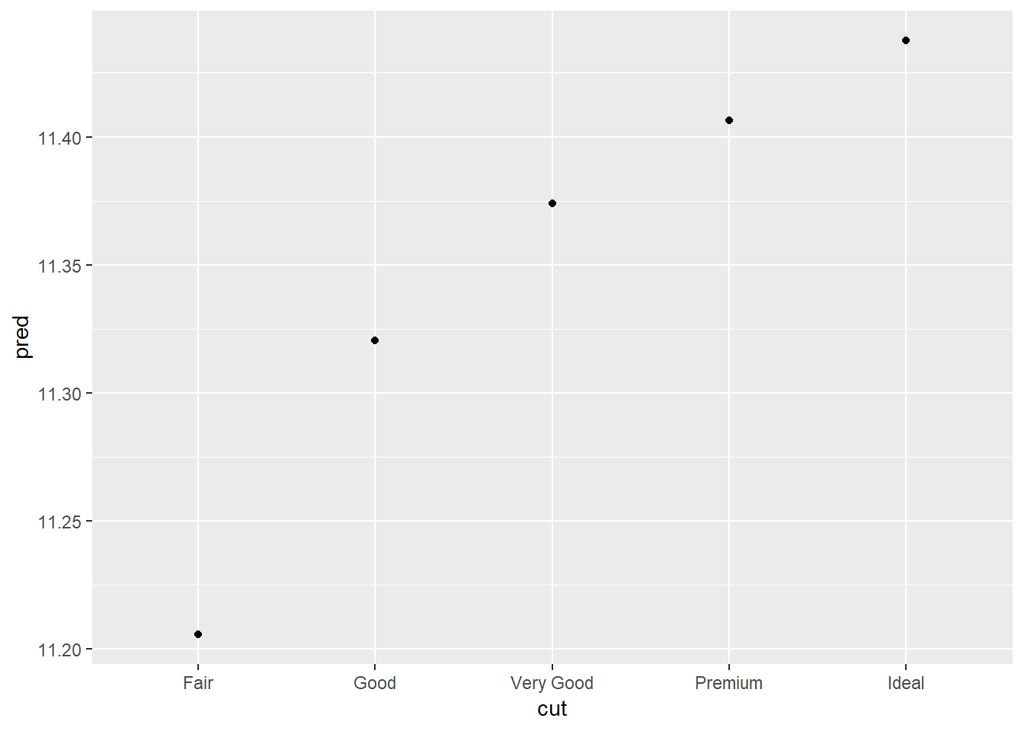

```r
ggplot(grid,aes(cut,pred))+
  geom_point()
```

If the model needs variables that you haven’t explicitly supplied, `data_grid()` will automatically fill them in with “typical” value. For continuous variables, it uses the median, and categorical variables it uses the most common value (or values, if there is a tie).

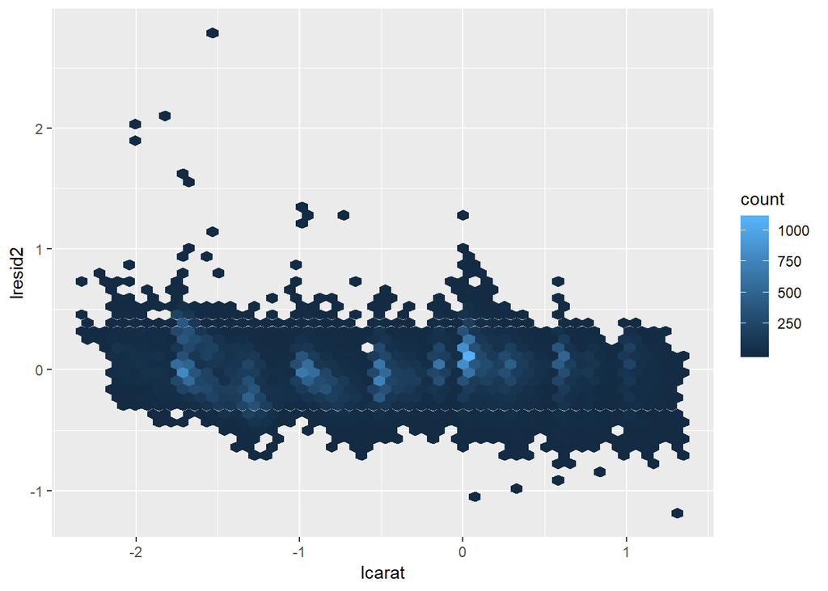

```r
diamonds2 <- diamonds2 %>%
  add_residuals(mod_diamonds2,"lresid2")

ggplot(diamonds2,aes(lcarat,lresid2))+
  geom_hex(bins=50)
```

This plot indicates that there are some diamonds with quite large residuals - remember a residual of 2 indicates that the diamond is 4x the price that we expected. It’s often useful to look at unusual values individually:

```r
diamonds2 %>%
  filter(abs(lresid2) > 1) %>%
  add_predictions(mod_diamond2) %>%
  mutate(pred = round(2 ^ pred)) %>%
  select(price, pred, carat:table, x:z) %>%
  arrange(price)
```

[output not shown]

Nothing really jumps out at me here, but it’s probably worth spending time considering if this indicates a problem with our model, or if there are errors in the data. If there are mistakes in the data, this could be an opportunity to buy diamonds that have been priced low incorrectly.

### 24.2.3 Exercises

1. In the plot of `lcarat` vs. `lprice`, there are some bright vertical strips. What do they represent?

2. If $log(price) = a_0 + a_1 * log(carat)$, what does that say about the relationship between price and carat?

That the price of a diamond is completely dependent on the carat size but only when the relationship is in a multiplicative or linear fashion. A 1% increase in carat is associated with a 1% increase in price.

3. Extract the diamonds that have very high and very low residuals. Is there anything unusual about these diamonds? Are they particularly bad or good, or do you think these are pricing errors?

```r
library(tidyverse)

diamonds2 <-
  diamonds %>%
  mutate(lprice=log2(price),
         lcarat=log2(carat))

mod1 <- lm(lprice~lcarat+color+clarity+cut,data=diamonds2)

bottom <-
  diamonds2 %>%
  add_residuals(mod1) %>%
  arrange(resid) %>%
  slice(1:10)

top <-
  diamonds2 %>%
  add_residuals(mod1) %>%
  arrange(-resid) %>%
  slice(1:10)

bind_rows(bottom,top) %>%
  select(price,carat,resid)
```

```
## # A tibble: 20 x 3
##    price carat  resid
##    <int> <dbl>  <dbl>
##  1  6512 3     -1.46
##  2 10470 2.46  -1.17
##  3 10453 3.05  -1.14
##  4 14220 3.01  -1.12
##  5  9925 3.01  -1.12
##  6 18701 3.51  -1.09
##  7  1262 1.03  -1.04
##  8  8040 3.01  -1.02
##  9 12587 3.5   -0.990
## 10  8044 3     -0.985
## 11  2160 0.34   2.81
## 12  1776 0.290  2.10
## 13  1186 0.25   2.06
## 14  1186 0.25   2.06
## 15  1013 0.25   1.94
## 16  2366 0.3    1.61
## 17  1715 0.32   1.57
## 18  4368 0.51   1.36
## 19 10011 1.01   1.31
## 20  3807 0.61   1.31
```

4. Does the final model, `mod_diamond2`, do a good job of predicting diamond prices? Would you trust it to tell you how much to spend if you were buying a diamond?

```r
diamonds2 %>%
  add_predictions(mod1) %>%
  mutate(pred=2^pred) %>%
  select(price,pred) %>%
  mutate(se=predict(mod1,se.fit=T)$se.fit,
         low_ci=pred-se*2,
         upper_ci=pred+se*2,
         correct=if_else(price>=low_ci&price<=upper_ci,TRUE,FALSE)) %>%
  summarise(prop_correct=mean(correct))
```

```
## # A tibble: 1 x 1
##   prop_correct
##          <dbl>
## 1            0
```

It doesn’t look like very good model at predicting because 0% of the predictions were close to the actual price. This is based on the 95% interval.

We could do it separately and check the magniturde of the residuals

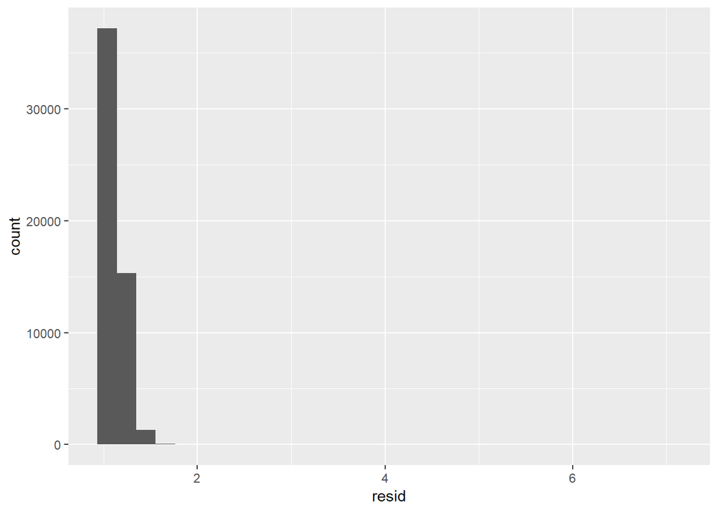

```r
diamonds2 %>%
  add_residuals(mod1) %>%
  mutate(resid=2^abs(resid)) %>%
  ggplot(aes(resid))+
  geom_histogram()
```

## 24.3 What affects the number of daily flights?

Let’s work through a similar process for a dataset that seems even simpler at first glance: the number of flights that leave NYC per day. This is a really small dataset — only 365 rows and 2 columns — and we’re not going to end up with a fully realised model, but as you’ll see, the steps along the way will help us better understand the data. Let’s get started by counting the number of flights per day and visualising it with ggplot2.

```r
library(tidyverse)
library(nycflights13)
library(lubridate)
library(ggplot2)
library(modelr)

# data overview
head(flights)
```

```
## # A tibble: 6 x 19
##    year month   day dep_time sched_dep_time dep_delay arr_time
##   <int> <int> <int>    <int>          <int>     <dbl>    <int>
## 1  2013     1     1      517            515         2      830
## 2  2013     1     1      533            529         4      850
## 3  2013     1     1      542            540         2      923
## 4  2013     1     1      544            545        -1     1004
## 5  2013     1     1      554            600        -6      812
## 6  2013     1     1      554            558        -4      740
## # ... with 12 more variables: sched_arr_time <int>, arr_delay <dbl>,
## #   carrier <chr>, flight <int>, tailnum <chr>, origin <chr>, dest <chr>,
## #   air_time <dbl>, distance <dbl>, hour <dbl>, minute <dbl>,
## #   time_hour <dttm>
```

```r
daily <- flights %>%
  mutate(date=make_date(year,month,day)) %>%
  group_by(date) %>%
  summarise(n=n())
head(daily)
```

```
## # A tibble: 6 x 2
##   date           n
##   <date>     <int>
## 1 2013-01-01   842
## 2 2013-01-02   943
## 3 2013-01-03   914
## 4 2013-01-04   915
## 5 2013-01-05   720
## 6 2013-01-06   832
```

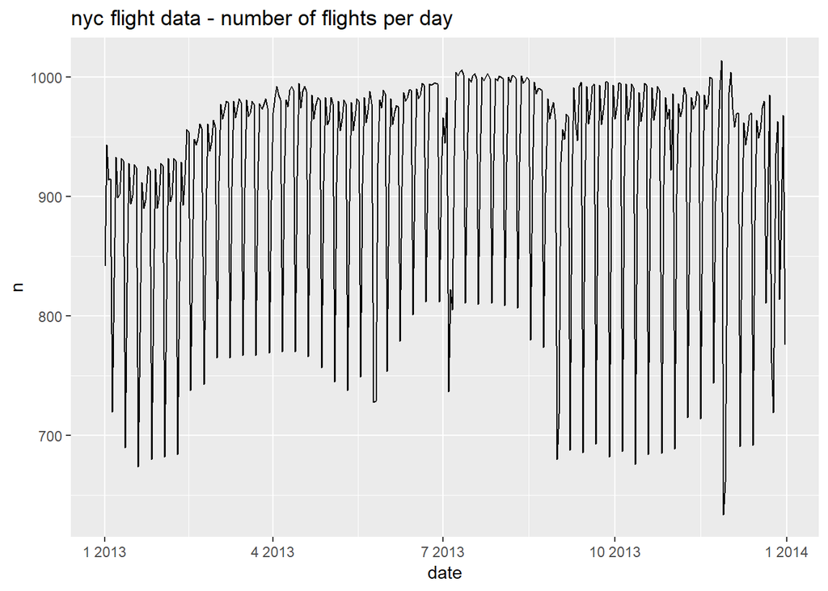

```r
# data plot
ggplot(data=daily)+
  geom_line(aes(x=date,y=n))+
  ggtitle("nyc flight data - number of flights per day")
```

```r
  ylab("number of flights per day")
```

```
## $y
## [1] "number of flights per day"
##
## attr(,"class")
## [1] "labels"
```

### 24.3.1 Day of Work

Understanding the long-term trend is challenging because there’s a very strong day-of-week effect that dominates the subtler patterns. Let’s start by looking at the distribution of flight numbers by day-of-week:

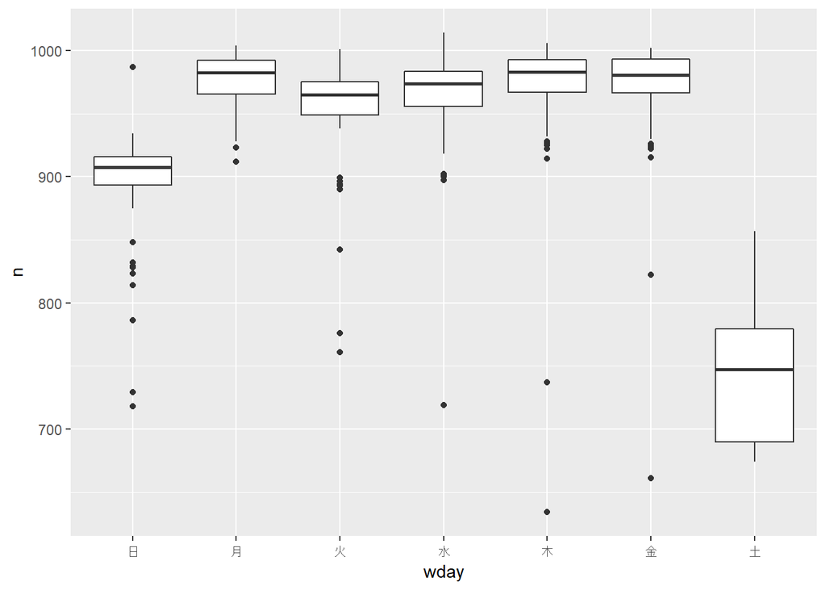

```r
daily <- daily %>%
  mutate(wday = wday(date, label = TRUE))
ggplot(daily, aes(wday, n)) +
  geom_boxplot()
```

There are fewer flights on weekends because most travel is for business. The effect is particularly pronounced on Saturday: you might sometimes leave on Sunday for a Monday morning meeting, but it’s very rare that you’d leave on Saturday as you’d much rather be at home with your family.

One way to remove this strong pattern is to use a model. First, we fit the model, and display its predictions overlaid on the original data:

```r
mod <- lm(n ~ wday, data = daily)
summary(mod)
```

```
##
## Call:
## lm(formula = n ~ wday, data = daily)
##
## Residuals:
##     Min      1Q  Median      3Q     Max
## -331.75   -8.69   12.31   25.19  112.38
##
## Coefficients:
##             Estimate Std. Error t value Pr(>|t|)
## (Intercept)  922.595      2.554 361.209   <2e-16 ***
## wday.L       -83.322      6.765 -12.317   <2e-16 ***
## wday.Q      -155.111      6.760 -22.945   <2e-16 ***
## wday.C       -62.834      6.756  -9.300   <2e-16 ***
## wday^4       -80.126      6.766 -11.842   <2e-16 ***
## wday^5        -4.967      6.748  -0.736   0.4622
## wday^6       -16.934      6.751  -2.508   0.0126 *
## ---
## Signif. codes:  0 '***' 0.001 '**' 0.01 '*' 0.05 '.' 0.1 ' ' 1
##
## Residual standard error: 48.8 on 358 degrees of freedom
## Multiple R-squared:  0.7178, Adjusted R-squared:  0.7131
## F-statistic: 151.8 on 6 and 358 DF,  p-value: < 2.2e-16
```

```r
grid <- daily %>%
  data_grid(wday) %>%
  add_predictions(mod,"n")
head(grid)
```

```
## # A tibble: 6 x 2
##   wday      n
##   <ord> <dbl>
## 1 日     891.
## 2 月     975.
## 3 火     951.
## 4 水     963.
## 5 木     966.
## 6 金     967.
```

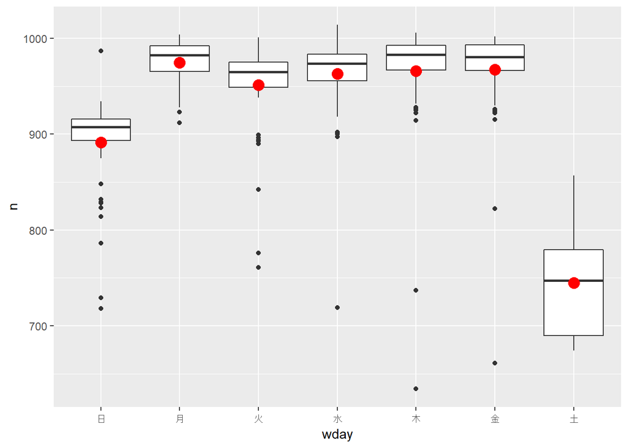

```r
ggplot(daily,aes(wday,n))+
  geom_boxplot()+
  geom_point(data=grid,colour="red",size=4)
```

Next we compute and visualise the residuals:

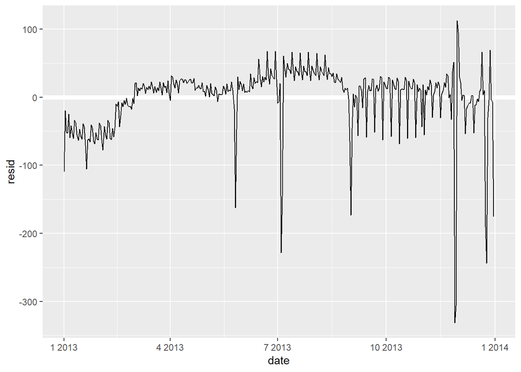

```r
daily <- daily %>%
  add_residuals(mod)

daily %>%
  ggplot(aes(date,resid))+
  geom_ref_line(h=0)+
  geom_line()
```

Note the change in the y-axis: now we are seeing the deviation from the expected number of flights, given the day of week. This plot is useful because now that we’ve removed much of the large day-of-week effect, we can see some of the subtler patterns that remain:

1. Our model seems to fail starting in June: you can still see a strong regular pattern that our model hasn’t captured. Drawing a plot with one line for each day of the week makes the cause easier to see:

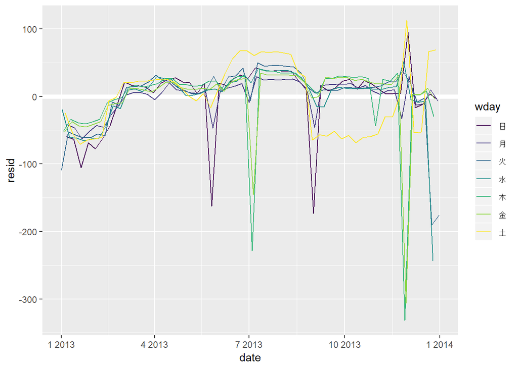

```r
ggplot(daily,aes(date,resid,colour=wday))+
  geom_ref_line(h=0)+
  geom_line()
```

Our model fails to accurately predict the number of flights on Saturday: during summer there are more flights than we expect, and during Fall there are fewer. We’ll see how we can do better to capture this pattern in the next section.

2. There are some days with far fewer flights than expected:

```r
daily %>%
  filter(resid < -100)
```

```
## # A tibble: 11 x 4
##    date           n wday  resid
##    <date>     <int> <ord> <dbl>
##  1 2013-01-01   842 火    -109.
##  2 2013-01-20   786 日    -105.
##  3 2013-05-26   729 日    -162.
##  4 2013-07-04   737 木    -229.
##  5 2013-07-05   822 金    -145.
##  6 2013-09-01   718 日    -173.
##  7 2013-11-28   634 木    -332.
##  8 2013-11-29   661 金    -306.
##  9 2013-12-24   761 火    -190.
## 10 2013-12-25   719 水    -244.
## 11 2013-12-31   776 火    -175.
```

If you’re familiar with American public holidays, you might spot New Year’s day, July 4th, Thanksgiving and Christmas. There are some others that don’t seem to correspond to public holidays. You’ll work on those in one of the exercises.

3. There seems to be some smoother long term trend over the course of the year. We can highlight that trend with `geom_smooth()`:

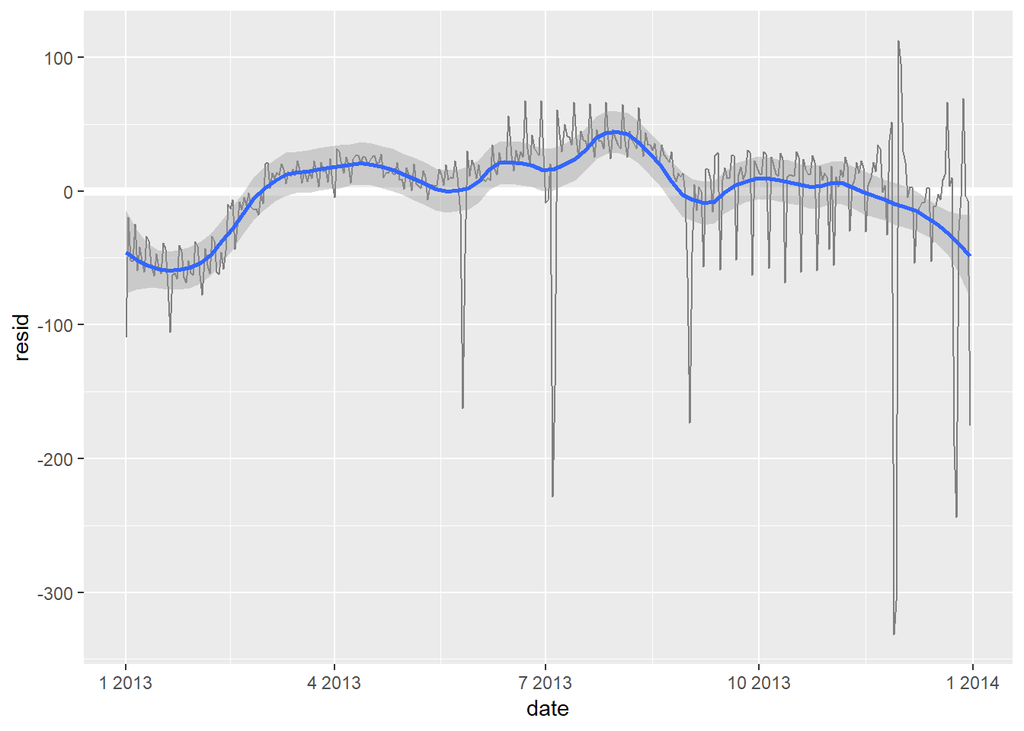

```r
daily %>%
  ggplot(aes(date,resid))+
  geom_ref_line(h=0)+
  geom_line(colour="grey50")+
  geom_smooth(se=TRUE,span=0.20)
```

There are fewer flights in January (and December), and more in summer (May-Sep). We can’t do much with this pattern quantitatively, because we only have a single year of data. But we can use our domain knowledge to brainstorm potential explanations.

### 24.3.2 Seasonal Saturday effect

Let’s first tackle our failure to accurately predict the number of flights on Saturday. A good place to start is to go back to the raw numbers, focussing on Saturdays:

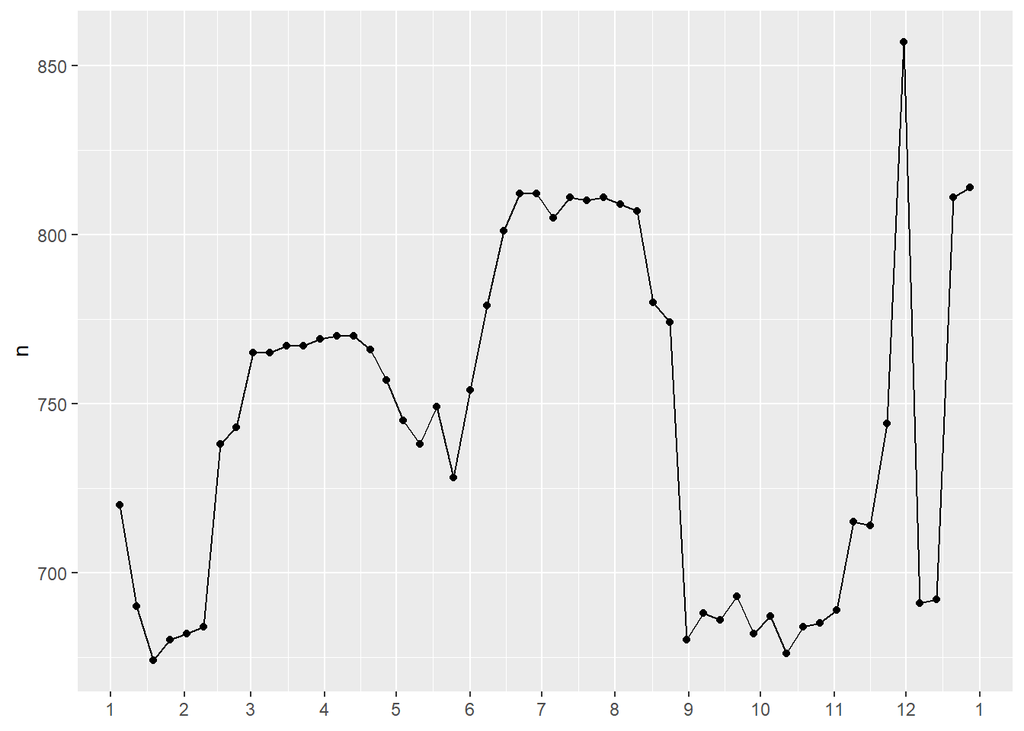

```r
daily %>%
  filter(wday=="土") %>%
  ggplot(aes(date,n))+
  geom_point()+
  geom_line()+
  scale_x_date(NULL,date_breaks = "1 month",date_labels="%b")
```

I have both points and lines to make it more clear what is data and what is interpolation.

I suspect this pattern is caused by summer holidays: many people go on holiday in the summer, and people don’t mind traveliing on Saturdays for vacation. . Looking at this plot, we might guess that summer holidays are from early June to late August. That seems to line up fairly well with the state’s school terms: summer break in 2013 was Jun 26–Sep 9.

Why are there more Saturday flights in the Spring than the Fall? I asked some American friends and they suggested that it’s less common to plan family vacations during the Fall because of the big Thanksgiving and Christmas holidays. We don’t have the data to know for sure, but it seems like a plausible working hypothesis.

Lets create a “term” variable that roughly captures the three school terms, and check our work with a plot:

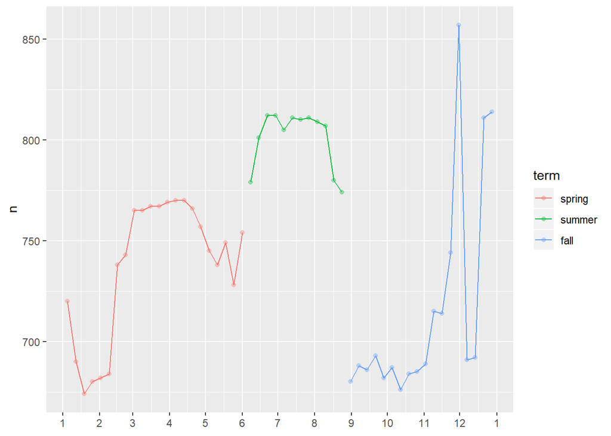

```r
library(lubridate)

term <- function(date){
  cut(date,
      breaks = ymd(20130101,20130605,20130825,20140101),
      labels=c("spring","summer","fall")
      )
}

daily <- daily %>%
  mutate(term = term(date))

daily %>%
  filter(wday=="土") %>%
  ggplot(aes(date,n,colour=term))+
  geom_point(alpha=1/3)+
  geom_line()+
  scale_x_date(NULL,date_breaks = "1 month",date_labels="%b")
```

(I manually tweaked the dates to get nice breaks in the plot. Using a visualisation to help you understand what your function is doing is a really powerful and general technique.)

It’s useful to see how this new variable affects the other days of the week:

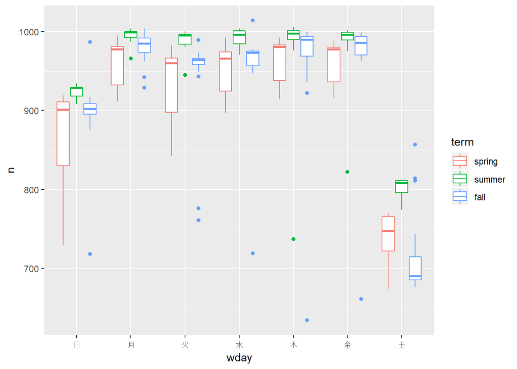

```r
daily %>%
  ggplot(aes(wday,n,colour=term))+
  geom_boxplot()
```

It looks like there is significant variation across the terms, so fitting a separate day of week effect for each term is reasonable. This improves our model, but not as much as we might hope:

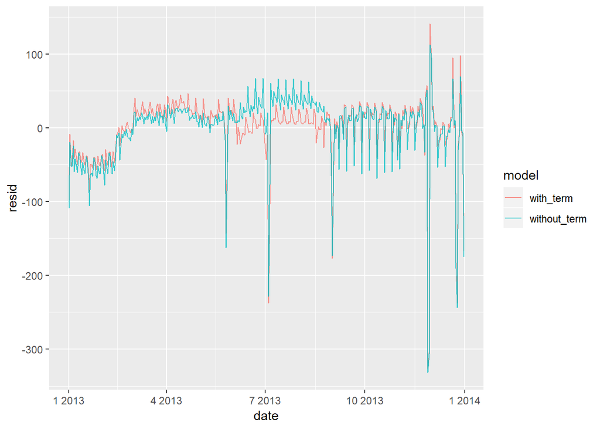

```r
mod1 <- lm(n ~ wday, data = daily)
mod2 <- lm(n ~ wday * term, data = daily)

daily %>%
  gather_residuals(without_term = mod1, with_term = mod2) %>%
  ggplot(aes(date, resid, colour = model)) +
    geom_line(alpha = 0.75)
```

We can see the problem by overlaying the predictions from the model on to the raw data:

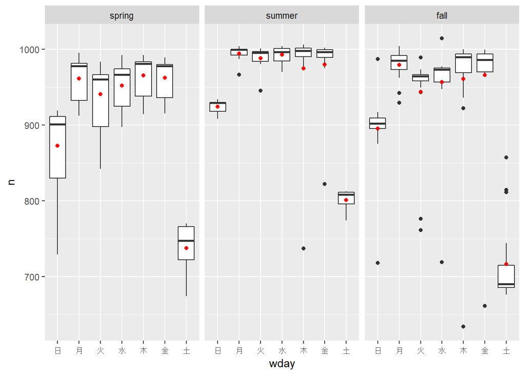

```r
grid <- daily %>%
  data_grid(wday,term) %>%
  add_predictions(mod2,"n")

ggplot(daily,aes(wday,n))+
  geom_boxplot()+
  geom_point(data=grid,colour="red")+
  facet_wrap(~term)
```

Our model is finding the mean effect, but we have a lot of big outliers, so mean tends to be far away from the typical value. We can alleviate this problem by using a model that is robust to the effect of outliers: `MASS::rlm()`. This greatly reduces the impact of the outliers on our estimates, and gives a model that does a good job of removing the day of week pattern:

```r
head(daily)
```

```
## # A tibble: 6 x 5
##   date           n wday   resid term
##   <date>     <int> <ord>  <dbl> <fct>
## 1 2013-01-01   842 火    -109.  spring
## 2 2013-01-02   943 水     -19.7 spring
## 3 2013-01-03   914 木     -51.8 spring
## 4 2013-01-04   915 金     -52.5 spring
## 5 2013-01-05   720 土     -24.6 spring
## 6 2013-01-06   832 日     -59.5 spring
```

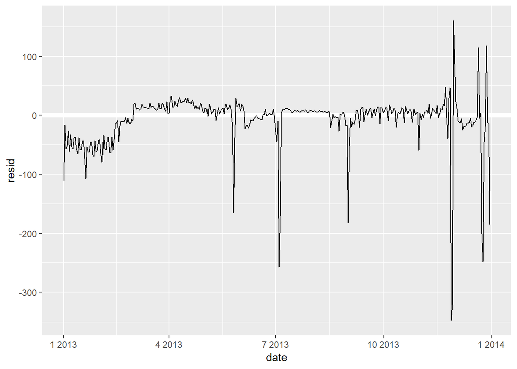

```r
mod3 <- MASS::rlm(n~wday*term,data=daily)

daily %>%
  add_residuals(mod3,"resid") %>%
  ggplot(aes(date,resid))+
  geom_hline(yintercept=0,size=2,colour="white")+
  geom_line()
```

It’S now much easier to see the long-term trend, and the positive and negative outliers.

### 24.3.3 Computed variables

If you are experimenting with many models and many visualizations, It’s a good idea to bundle the creation of variables up into a function so there is no chance of accidentally applying a different transformation in different places.

For example, we could write

```r
compute_vars <- function(data) {
  data %>%
    mutate(
      term = term(date),
      wday = wday(date, label = TRUE)
    )
}
```

Another option is to put the transformations directly in the model formula:

```r
wday2 <- function(x) wday(x, label = TRUE)
mod3 <- lm(n ~ wday2(date) * term(date), data = daily)
```

Either approach is reasonable. Making the transformed variable explicit is useful if you want to check your work, or use them in a visualisation. But you can’t easily use transformations (like splines) that return multiple columns. Including the transformations in the model function makes life a little easier when you’re working with many different datasets because the model is self contained.

### 24.3.4 Time of year: an alternative approach

In the previous section we used our domain knowledge (how the US school term affects travel) to improve the model. An alternative to using our knowledge explicitly in the model is to give the data more room to speak. We could use a more flexible model and allow that to capture the pattern we’re interested in. A simple linear trend isn’t adequate, so we could try using a natural spline to fit a smooth curve across the year:

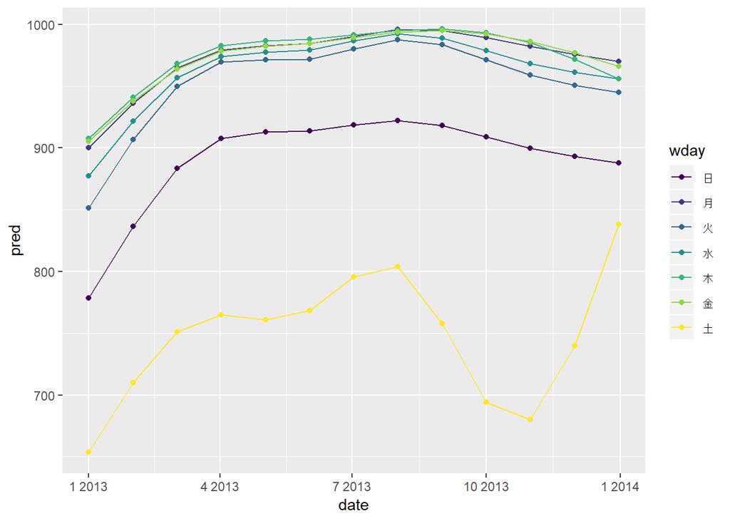

```r
library(splines)
library(magrittr)
library(modelr)
library(tidyverse)

mod <- MASS::rlm(n ~ wday * ns(date, 5), data = daily)

daily %>%
  data_grid(wday, date = seq_range(date, n = 13)) %>%
  add_predictions(mod) %>%
  ggplot(aes(date, pred, colour = wday)) +
    geom_line() +
    geom_point()
```

We see a strong pattern in the numbers of Saturday flights. This is reassuring, because we also saw that pattern in the raw data. It’s a good sign when you get the same signal from different approaches.

## 24.4 Learning more about models

We have only scratched the absolute surface of modelling, but you have hopefully gained some simple, but general-purpose tools that you can use to improve your own data analyses. It’s OK to start simple! As you’ve seen, even very simple models can make a dramatic difference in your ability to tease out interactions between variables.

These modelling chapters are even more opinionated than the rest of the book. I approach modelling from a somewhat different perspective to most others, and there is relatively little space devoted to it. Modelling really deserves a book on its own, so I’d highly recommend that you read at least one of these three books:

- Statistical Modeling: A Fresh Approach by Danny Kaplan, http://www.mosaic-web.org/go/StatisticalModeling/. This book provides a gentle introduction to modelling, where you build your intuition, mathematical tools, and R skills in parallel. The book replaces a traditional “introduction to statistics” course, providing a curriculum that is up-to-date and relevant to data science.
- An Introduction to Statistical Learning by Gareth James, Daniela Witten, Trevor Hastie, and Robert Tibshirani, http://www-bcf.usc.edu/~gareth/ISL/ (available online for free). This book presents a family of modern modelling techniques collectively known as statistical learning. For an even deeper understanding of the math behind the models, read the classic Elements of Statistical Learning by Trevor Hastie, Robert Tibshirani, and Jerome Friedman, http://statweb.stanford.edu/~tibs/ElemStatLearn/ (also available online for free).
- Applied Predictive Modeling by Max Kuhn and Kjell Johnson, http://appliedpredictivemodeling.com. This book is a companion to the caret package and provides practical tools for dealing with real-life predictive modelling challenges.

# Chapter 25: Many models

## 25.1 Introduction

In this chapter, you are going to learn thre powerful ideas that help you to work with large numbers of models with ease:

1. Using many simple models to better understand complex datasets.
2. Using list-columns to store arbitrary data structures in a data frame. For example, this will allow you to have a column that contains linear models.
3. Using the **broom** package, by David Robinson, to turn models into tidy data. This is a powerful technique for working with large numbers of models because once you have tidy data, you can apply all of the techniques that you’ve learned about earlier in the book.

We’ll start by diving into a motivating example using data about life expectancy around the world. It’s a small dataset but it illustrates how important modelling can be for improving your visualisations. We’ll use a large number of simple models to partition out some of the strongest signals so we can see the subtler signals that remain. We’ll also see how model summaries can help us pick out outliers and unusual trends.

The following sectins will dive into more details about the individual techniques:

1. In [list-columns](http://r4ds.had.co.nz/many-models.html#list-columns-1), you’ll learn more about the list-column data structure, and why it’s valid to put lists in data frames.
2. In [creating list-columns](http://r4ds.had.co.nz/many-models.html#creating-list-columns), you’ll learn the three main ways in which you’ll create list-columns.
3. In [simplifying list-columns](http://r4ds.had.co.nz/many-models.html#simplifying-list-columns) you’ll learn how to convert list-columns back to regular atomic vectors (or sets of atomic vectors) so you can work with them more easily.
4. In [making tidy data with broom](http://r4ds.had.co.nz/many-models.html#making-tidy-data-with-broom), you’ll learn about the full set of tools provided by broom, and see how they can be applied to other types of data structure.

### 25.1.1 Prerequisites

Working with many models requires many of the packages of the tidyverse (for data exploration, wrangling, and programming) and modelr to facilitate modelling.

```r
library(modelr)
library(tidyverse)
```

## 25.2 gapminder

To motivate the power of many simple models, we’re going to look into the “gapminder” data. This data was popularised by Hans Rosling, a Swedish doctor and statistician. If you’ve never heard of him, stop reading this chapter right now and go watch one of his videos! He is a fantastic data presenter and illustrates how you can use data to present a compelling story. A good place to start is this short video filmed in conjunction with the BBC: https://www.youtube.com/watch?v=jbkSRLYSojo.

The gapminder data summarises the progression of countries over time, looking at statistics like life expectancy and GDP. The data is easy to access in R, thanks to Jenny Bryan who created the gapminder package:

```r
# install.packages("gapminder")
library(gapminder)
gapminder
```

```
## # A tibble: 1,704 x 6
##    country     continent  year lifeExp      pop gdpPercap
##    <fct>       <fct>     <int>   <dbl>    <int>     <dbl>
##  1 Afghanistan Asia       1952    28.8  8425333      779.
##  2 Afghanistan Asia       1957    30.3  9240934      821.
##  3 Afghanistan Asia       1962    32.0 10267083      853.
##  4 Afghanistan Asia       1967    34.0 11537966      836.
##  5 Afghanistan Asia       1972    36.1 13079460      740.
##  6 Afghanistan Asia       1977    38.4 14880372      786.
##  7 Afghanistan Asia       1982    39.9 12881816      978.
##  8 Afghanistan Asia       1987    40.8 13867957      852.
##  9 Afghanistan Asia       1992    41.7 16317921      649.
## 10 Afghanistan Asia       1997    41.8 22227415      635.
## # ... with 1,694 more rows
```

In this case study, we’re going to focus on just three variables to answer the questions “How does life expentancy (`lifeExp`) change over time(`year`) for each country(`country`)?” A good place to start is with a plot:

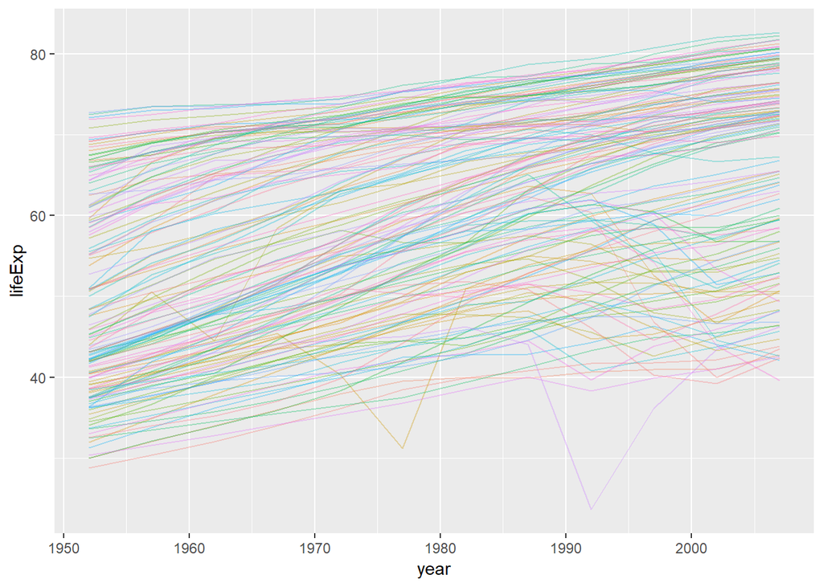

```r
library(magrittr)
gapminder %>%
  ggplot(aes(x=year,y=lifeExp,group=country,colour=country))+
  geom_line(alpha=1/3,show.legend = F)
```

This is a small dataset: it only has ~1,700 observations and 3 variables. But it’s still hard to see what’s going on! Overall, it looks like life expectancy has been steadily improving. However, if you look closely, you might notice some countries that don’t follow this pattern. How can we make those countries easier to see?

One way is to use the same approach as in the last chapter: there’s a strong signal (overall linear growth) that makes it hard to see subtler trends. We’ll tease these factors apart by fitting a model with a linear trend. The model captures steady growth over time, and the residuals will show what’s left.

You always know how to do that if we had a single country:

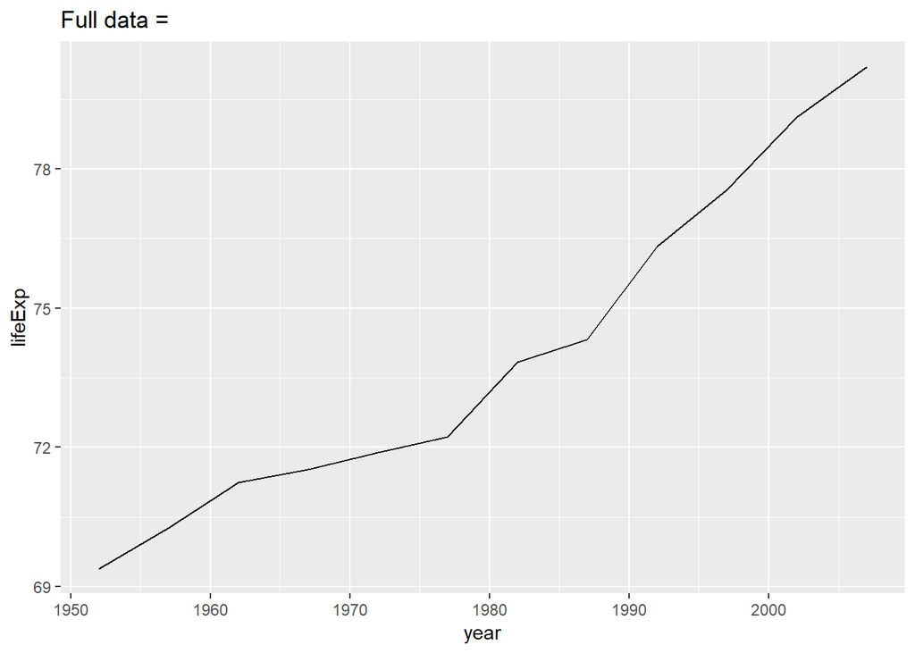

```r
par(mfrow=c(1,3))

nz <- filter(gapminder,country=="New Zealand")
nz %>%
  ggplot(aes(year,lifeExp))+
  geom_line()+
  ggtitle("Full data =")
```

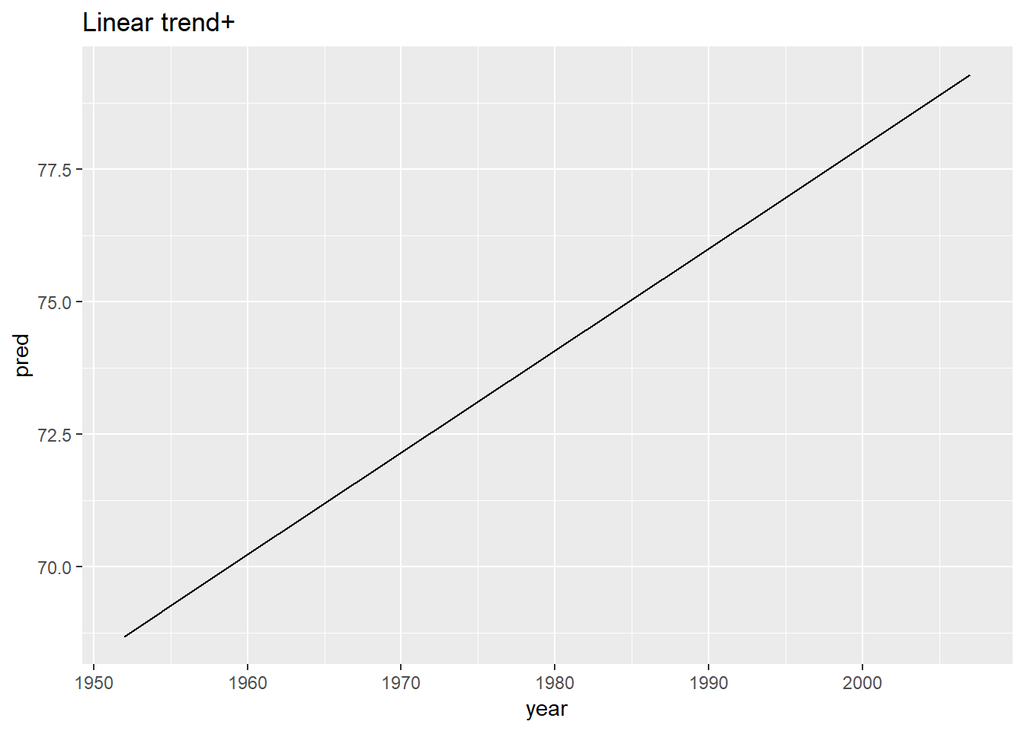

```r
nz_mod <- lm(lifeExp~year,data=nz)
nz %>%
  add_predictions(nz_mod) %>%
  ggplot(aes(year,pred))+
  geom_line()+
  ggtitle("Linear trend+")
```

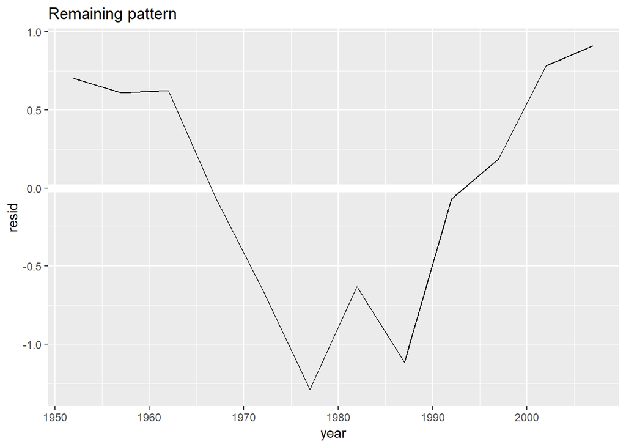

```r
nz %>%
  add_residuals(nz_mod) %>%
  ggplot(aes(year, resid)) +
  geom_hline(yintercept = 0, colour = "white", size = 3) +
  geom_line() +
  ggtitle("Remaining pattern")
```

How can we easily fit that model to every country?

### 25.2.1 Nested data

You could imagine copy and pasting that code multiple times; but you’ve already learnt a better way! Extract out the common code with a function and repeat using a map function from purrr. This problem is structured a little differently to what you’ve seen before. Instead of repeating an action for each variable, we want to repeat an action for each country, a subset of rows. To do that, we need a new data structure: the **nested data frame**. To create a nested data frame we start with a grouped data frame, and “nest” it:

```r
head(gapminder)
```

```
## # A tibble: 6 x 6
##   country     continent  year lifeExp      pop gdpPercap
##   <fct>       <fct>     <int>   <dbl>    <int>     <dbl>
## 1 Afghanistan Asia       1952    28.8  8425333      779.
## 2 Afghanistan Asia       1957    30.3  9240934      821.
## 3 Afghanistan Asia       1962    32.0 10267083      853.
## 4 Afghanistan Asia       1967    34.0 11537966      836.
## 5 Afghanistan Asia       1972    36.1 13079460      740.
## 6 Afghanistan Asia       1977    38.4 14880372      786.
```

```r
by_country <- gapminder %>%
  group_by(country,continent) %>%
  nest()

by_country
```

```
## # A tibble: 142 x 3
##    country     continent data
##    <fct>       <fct>     <list>
##  1 Afghanistan Asia      <tibble [12 x 4]>
##  2 Albania     Europe    <tibble [12 x 4]>
##  3 Algeria     Africa    <tibble [12 x 4]>
##  4 Angola      Africa    <tibble [12 x 4]>
##  5 Argentina   Americas  <tibble [12 x 4]>
##  6 Australia   Oceania   <tibble [12 x 4]>
##  7 Austria     Europe    <tibble [12 x 4]>
##  8 Bahrain     Asia      <tibble [12 x 4]>
##  9 Bangladesh  Asia      <tibble [12 x 4]>
## 10 Belgium     Europe    <tibble [12 x 4]>
## # ... with 132 more rows
```

(I’m cheating a little by grouping on both `continent` and `country`. Given `country`, `continent` is fixed, so this doesn’t add any more groups, but it’s an easy way to carry an extra variable along for the ride.)

This creates a data frame that has one row per group (per `country`), and a rather unusual column: `data`. `data` is a list of data frames (or tibbles, to be precise). This seems like a crazy idea: we have a data frame with a column that is a list of other data frames! I’ll explain shortly why I think this is a good idea.

The `data` column is a little tricky to look at because it’s a moderately complicated list, and we’re still working on good tools to explore these objects. Unfortunately using `str()` is not recommended as it will often produce very long output. But if you pluck out a single element from the `data` column you’ll see that it contains all the data for that country (in this case, Afghanistan).

```r
by_country$data[[1]]
```

```
## # A tibble: 12 x 4
##     year lifeExp      pop gdpPercap
##    <int>   <dbl>    <int>     <dbl>
##  1  1952    28.8  8425333      779.
##  2  1957    30.3  9240934      821.
##  3  1962    32.0 10267083      853.
##  4  1967    34.0 11537966      836.
##  5  1972    36.1 13079460      740.
##  6  1977    38.4 14880372      786.
##  7  1982    39.9 12881816      978.
##  8  1987    40.8 13867957      852.
##  9  1992    41.7 16317921      649.
## 10  1997    41.8 22227415      635.
## 11  2002    42.1 25268405      727.
## 12  2007    43.8 31889923      975.
```

Note the difference between a standard grouped data frame and a neted data frame: in a grouped data frame, each row is an observation; in a nested data frame, each row is a group. Another way to think about a nested dataset is we now have a meta-observation: a row that represents the complete time course for a country, rather than a single point in time.

### 25.2.2 List-columns

Now that we have our nested data frame, we’re in a good position to fit some models. We have a model-fitting function:

```r
country_model <- function(df){
  lm(lifeExp ~ year, data=df)
}
```

And we want to apply it to every data frame. The data frames are in a list, so we can use `purrr:map()` to apply `country_model` to each element:

```r
models <- map(by_country$data,country_model)
```

However, rather than leaving the list of models as a free-floating object, I think it’s better to store it as a column in the `by_country` data frame. Storing related objects in columns is a key part of the value of data frames, and why I think list-columns are such a good idea. In the course of working with these countries, we are going to have lots of lists where we have one element per country. So why not store them all together in one data frame?

In other words, instead of creating a new object in the global environment, we’re going to create a new variable in the by_country data frame. That’s a job for `dplyr::mutate()`:

```r
by_country <- by_country %>%
  mutate(model=map(data,country_model))
by_country
```

```
## # A tibble: 142 x 4
##    country     continent data              model
##    <fct>       <fct>     <list>            <list>
##  1 Afghanistan Asia      <tibble [12 x 4]> <S3: lm>
##  2 Albania     Europe    <tibble [12 x 4]> <S3: lm>
##  3 Algeria     Africa    <tibble [12 x 4]> <S3: lm>
##  4 Angola      Africa    <tibble [12 x 4]> <S3: lm>
##  5 Argentina   Americas  <tibble [12 x 4]> <S3: lm>
##  6 Australia   Oceania   <tibble [12 x 4]> <S3: lm>
##  7 Austria     Europe    <tibble [12 x 4]> <S3: lm>
##  8 Bahrain     Asia      <tibble [12 x 4]> <S3: lm>
##  9 Bangladesh  Asia      <tibble [12 x 4]> <S3: lm>
## 10 Belgium     Europe    <tibble [12 x 4]> <S3: lm>
## # ... with 132 more rows
```

```r
# by_country$data[[1]]
by_country$model[[1]]
```

```
##
## Call:
## lm(formula = lifeExp ~ year, data = df)
##
## Coefficients:
## (Intercept)         year
##   -507.5343       0.2753
```

This has a big advantage: because all the related objects are stored together, you don’t need to manually keep them in sync when you filter or arrange. The semantics of the data frame takes care of that for you:

```r
by_country %>%
  filter(continent=="Europe")
```

```
## # A tibble: 30 x 4
##    country                continent data              model
##    <fct>                  <fct>     <list>            <list>
##  1 Albania                Europe    <tibble [12 x 4]> <S3: lm>
##  2 Austria                Europe    <tibble [12 x 4]> <S3: lm>
##  3 Belgium                Europe    <tibble [12 x 4]> <S3: lm>
##  4 Bosnia and Herzegovina Europe    <tibble [12 x 4]> <S3: lm>
##  5 Bulgaria               Europe    <tibble [12 x 4]> <S3: lm>
##  6 Croatia                Europe    <tibble [12 x 4]> <S3: lm>
##  7 Czech Republic         Europe    <tibble [12 x 4]> <S3: lm>
##  8 Denmark                Europe    <tibble [12 x 4]> <S3: lm>
##  9 Finland                Europe    <tibble [12 x 4]> <S3: lm>
## 10 France                 Europe    <tibble [12 x 4]> <S3: lm>
## # ... with 20 more rows
```

```r
by_country %>%
  arrange(continent,country)
```

```
## # A tibble: 142 x 4
##    country                  continent data              model
##    <fct>                    <fct>     <list>            <list>
##  1 Algeria                  Africa    <tibble [12 x 4]> <S3: lm>
##  2 Angola                   Africa    <tibble [12 x 4]> <S3: lm>
##  3 Benin                    Africa    <tibble [12 x 4]> <S3: lm>
##  4 Botswana                 Africa    <tibble [12 x 4]> <S3: lm>
##  5 Burkina Faso             Africa    <tibble [12 x 4]> <S3: lm>
##  6 Burundi                  Africa    <tibble [12 x 4]> <S3: lm>
##  7 Cameroon                 Africa    <tibble [12 x 4]> <S3: lm>
##  8 Central African Republic Africa    <tibble [12 x 4]> <S3: lm>
##  9 Chad                     Africa    <tibble [12 x 4]> <S3: lm>
## 10 Comoros                  Africa    <tibble [12 x 4]> <S3: lm>
## # ... with 132 more rows
```

If your list of data frames and list of models were separate objects, you have to remember that whenever you re-order or subset one vector, you need to re-order or subset all the others in order to keep them in sync. If you forget, your code will continue to work, but it will give the wrong answer!

### 25.2.3 Unnesting

Previously we computed the residuals of a single model with a single dataset. Now we have 142 data frames and 142 models. To compute the residuals, we need to call `add_residuals()` with each model-data pair:

```r
library(modelr)

by_country <- by_country %>%
  mutate(
    resids = map2(data, model, add_residuals)
  )
by_country
```

```
## # A tibble: 142 x 5
##    country     continent data              model    resids
##    <fct>       <fct>     <list>            <list>   <list>
##  1 Afghanistan Asia      <tibble [12 x 4]> <S3: lm> <tibble [12 x 5]>
##  2 Albania     Europe    <tibble [12 x 4]> <S3: lm> <tibble [12 x 5]>
##  3 Algeria     Africa    <tibble [12 x 4]> <S3: lm> <tibble [12 x 5]>
##  4 Angola      Africa    <tibble [12 x 4]> <S3: lm> <tibble [12 x 5]>
##  5 Argentina   Americas  <tibble [12 x 4]> <S3: lm> <tibble [12 x 5]>
##  6 Australia   Oceania   <tibble [12 x 4]> <S3: lm> <tibble [12 x 5]>
##  7 Austria     Europe    <tibble [12 x 4]> <S3: lm> <tibble [12 x 5]>
##  8 Bahrain     Asia      <tibble [12 x 4]> <S3: lm> <tibble [12 x 5]>
##  9 Bangladesh  Asia      <tibble [12 x 4]> <S3: lm> <tibble [12 x 5]>
## 10 Belgium     Europe    <tibble [12 x 4]> <S3: lm> <tibble [12 x 5]>
## # ... with 132 more rows
```

But how you can plot a list of data frames? Instead of struggling to answer that question, let’s turn the list of data frames back into a regular data frame. Previously we used `nest()` to turn a regular data frame into an nested data frame, and now we do the opposite with `unnest()`:

```r
resids <- unnest(by_country,resids)
resids
```

```
## # A tibble: 1,704 x 7
##    country     continent  year lifeExp      pop gdpPercap   resid
##    <fct>       <fct>     <int>   <dbl>    <int>     <dbl>   <dbl>
##  1 Afghanistan Asia       1952    28.8  8425333      779. -1.11
##  2 Afghanistan Asia       1957    30.3  9240934      821. -0.952
##  3 Afghanistan Asia       1962    32.0 10267083      853. -0.664
##  4 Afghanistan Asia       1967    34.0 11537966      836. -0.0172
##  5 Afghanistan Asia       1972    36.1 13079460      740.  0.674
##  6 Afghanistan Asia       1977    38.4 14880372      786.  1.65
##  7 Afghanistan Asia       1982    39.9 12881816      978.  1.69
##  8 Afghanistan Asia       1987    40.8 13867957      852.  1.28
##  9 Afghanistan Asia       1992    41.7 16317921      649.  0.754
## 10 Afghanistan Asia       1997    41.8 22227415      635. -0.534
## # ... with 1,694 more rows
```

Note that each regular column is repeated one for each row in the nested column.

Now we have regular data frame, we can plot the residuals:

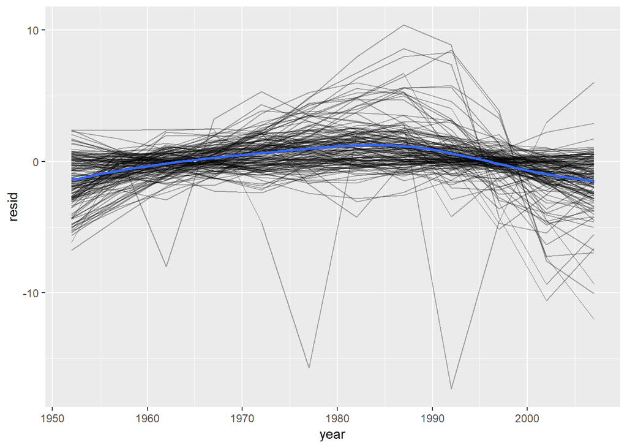

```r
resids %>%
  ggplot(aes(year,resid))+
  geom_line(aes(group=country),alpha=1/3)+
  geom_smooth(se=FALSE)
```

```r
# > `geom_smooth()` using method=`gam` and formula `y~s(x,bs="cs")`
```

Facetting by countinent is particularly revealing:

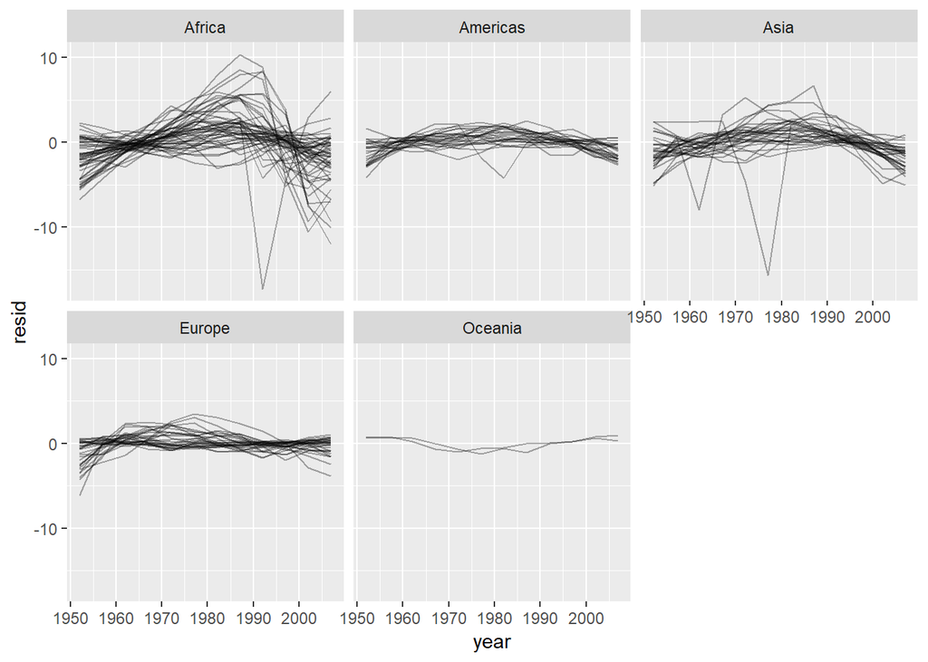

```r
resids %>%
  ggplot(aes(year,resid,group=country))+
  geom_line(alpha=1/3)+
  facet_wrap(~continent)
```

It looks like we’ve missed some patterns. There’s also something intersting going on in Africa: we see some very large residuals which suggests our model isn’t fitting so well there. We’ll explore that more in the next section, attacking it from a slightly different angle.

### 25.2.4 Model quality

Instead of looking at the residuals from the model, we could look at some general measurements of model quality. You learned how to compute some specific measures in the previous chapter. Here we’ll show a different approach using the broom package. The broom package provides a general set of functions to turn models into tidy data. Here we’ll use `broom::glance()` to extract some model quality metrics. If we apply it to a model, we get a data frame with a single row:

```r
broom::glance(nz_mod)
```

```
##   r.squared adj.r.squared     sigma statistic      p.value df    logLik
## 1 0.9535846     0.9489431 0.8043472  205.4459 5.407324e-08  2 -13.32064
##        AIC    BIC deviance df.residual
## 1 32.64128 34.096 6.469743          10
```

We can use `mutate()` and `unnest()` to create a data frame with a row for each country:

```r
by_country %>%
  mutate(glance=map(model,broom::glance)) %>%
  unnest(glance)
```

```
## # A tibble: 142 x 16
##    country continent data  model resids r.squared adj.r.squared sigma
##    <fct>   <fct>     <lis> <lis> <list>     <dbl>         <dbl> <dbl>
##  1 Afghan~ Asia      <tib~ <S3:~ <tibb~     0.948         0.942 1.22
##  2 Albania Europe    <tib~ <S3:~ <tibb~     0.911         0.902 1.98
##  3 Algeria Africa    <tib~ <S3:~ <tibb~     0.985         0.984 1.32
##  4 Angola  Africa    <tib~ <S3:~ <tibb~     0.888         0.877 1.41
##  5 Argent~ Americas  <tib~ <S3:~ <tibb~     0.996         0.995 0.292
##  6 Austra~ Oceania   <tib~ <S3:~ <tibb~     0.980         0.978 0.621
##  7 Austria Europe    <tib~ <S3:~ <tibb~     0.992         0.991 0.407
##  8 Bahrain Asia      <tib~ <S3:~ <tibb~     0.967         0.963 1.64
##  9 Bangla~ Asia      <tib~ <S3:~ <tibb~     0.989         0.988 0.977
## 10 Belgium Europe    <tib~ <S3:~ <tibb~     0.995         0.994 0.293
## # ... with 132 more rows, and 8 more variables: statistic <dbl>,
## #   p.value <dbl>, df <int>, logLik <dbl>, AIC <dbl>, BIC <dbl>,
## #   deviance <dbl>, df.residual <int>
```

[output not shown]

```r
glance <- by_country %>%
  mutate(glance=map(model,broom::glance)) %>%
  unnest(glance,drop=T)
glance
```

```
## # A tibble: 142 x 17
##    country continent data  model resids drop  r.squared adj.r.squared sigma
##    <fct>   <fct>     <lis> <lis> <list> <lgl>     <dbl>         <dbl> <dbl>
##  1 Afghan~ Asia      <tib~ <S3:~ <tibb~ TRUE      0.948         0.942 1.22
##  2 Albania Europe    <tib~ <S3:~ <tibb~ TRUE      0.911         0.902 1.98
##  3 Algeria Africa    <tib~ <S3:~ <tibb~ TRUE      0.985         0.984 1.32
##  4 Angola  Africa    <tib~ <S3:~ <tibb~ TRUE      0.888         0.877 1.41
##  5 Argent~ Americas  <tib~ <S3:~ <tibb~ TRUE      0.996         0.995 0.292
##  6 Austra~ Oceania   <tib~ <S3:~ <tibb~ TRUE      0.980         0.978 0.621
##  7 Austria Europe    <tib~ <S3:~ <tibb~ TRUE      0.992         0.991 0.407
##  8 Bahrain Asia      <tib~ <S3:~ <tibb~ TRUE      0.967         0.963 1.64
##  9 Bangla~ Asia      <tib~ <S3:~ <tibb~ TRUE      0.989         0.988 0.977
## 10 Belgium Europe    <tib~ <S3:~ <tibb~ TRUE      0.995         0.994 0.293
## # ... with 132 more rows, and 8 more variables: statistic <dbl>,
## #   p.value <dbl>, df <int>, logLik <dbl>, AIC <dbl>, BIC <dbl>,
## #   deviance <dbl>, df.residual <int>
```

(Pay attention to the variables that aren’t printed: there’s a lot of useful stuff there.)

With this data frame in hand, we can start to look for models that don’t fit well:

```r
glance %>%
  arrange(r.squared)
```

```
## # A tibble: 142 x 17
##    country continent data  model resids drop  r.squared adj.r.squared sigma
##    <fct>   <fct>     <lis> <lis> <list> <lgl>     <dbl>         <dbl> <dbl>
##  1 Rwanda  Africa    <tib~ <S3:~ <tibb~ TRUE     0.0172      -0.0811   6.56
##  2 Botswa~ Africa    <tib~ <S3:~ <tibb~ TRUE     0.0340      -0.0626   6.11
##  3 Zimbab~ Africa    <tib~ <S3:~ <tibb~ TRUE     0.0562      -0.0381   7.21
##  4 Zambia  Africa    <tib~ <S3:~ <tibb~ TRUE     0.0598      -0.0342   4.53
##  5 Swazil~ Africa    <tib~ <S3:~ <tibb~ TRUE     0.0682      -0.0250   6.64
##  6 Lesotho Africa    <tib~ <S3:~ <tibb~ TRUE     0.0849      -0.00666  5.93
##  7 Cote d~ Africa    <tib~ <S3:~ <tibb~ TRUE     0.283        0.212    3.93
##  8 South ~ Africa    <tib~ <S3:~ <tibb~ TRUE     0.312        0.244    4.74
##  9 Uganda  Africa    <tib~ <S3:~ <tibb~ TRUE     0.342        0.276    3.19
## 10 Congo,~ Africa    <tib~ <S3:~ <tibb~ TRUE     0.348        0.283    2.43
## # ... with 132 more rows, and 8 more variables: statistic <dbl>,
## #   p.value <dbl>, df <int>, logLik <dbl>, AIC <dbl>, BIC <dbl>,
## #   deviance <dbl>, df.residual <int>
```

The worst models all appear to be in Africa. Let’s double check that with a plot. Here we have a relatively small number of observations and a discrete variable, so `geom_jitter()` is effective:

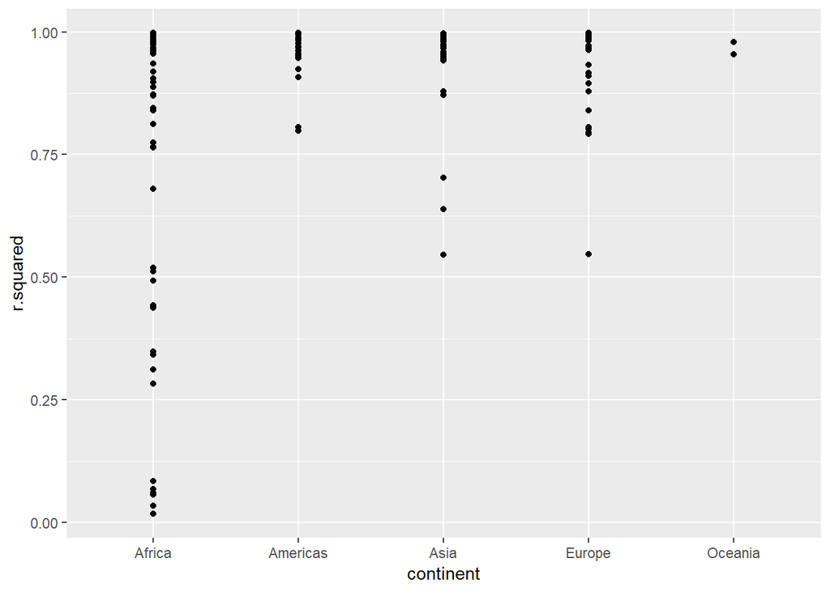

```r
glance %>%
  ggplot(aes(continent,r.squared))+
  geom_point()
```

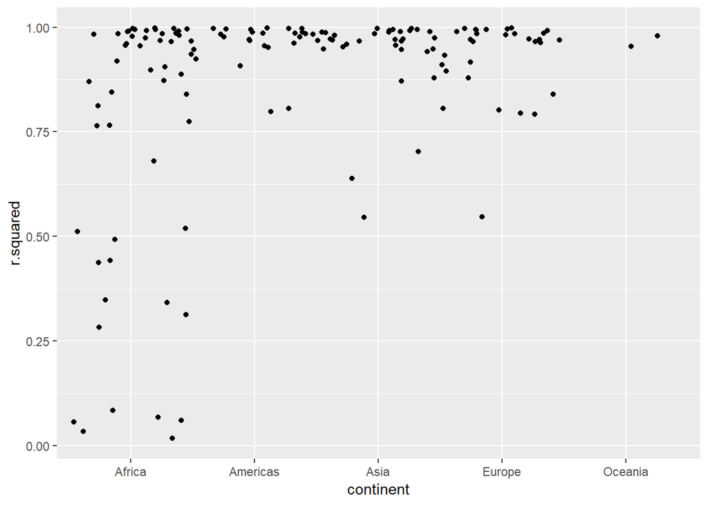

```r
glance %>%
  ggplot(aes(continent,r.squared))+
  geom_jitter(width=0.5)
```

We could pull out the countries with particularly bad $R^2$ and plot the data:

```r
library(gapminder)
bad_fit <- filter(glance,r.squared<0.25)
bad_fit
```

```
## # A tibble: 6 x 17
##   country continent data  model resids drop  r.squared adj.r.squared sigma
##   <fct>   <fct>     <lis> <lis> <list> <lgl>     <dbl>         <dbl> <dbl>
## 1 Botswa~ Africa    <tib~ <S3:~ <tibb~ TRUE     0.0340      -0.0626   6.11
## 2 Lesotho Africa    <tib~ <S3:~ <tibb~ TRUE     0.0849      -0.00666  5.93
## 3 Rwanda  Africa    <tib~ <S3:~ <tibb~ TRUE     0.0172      -0.0811   6.56
## 4 Swazil~ Africa    <tib~ <S3:~ <tibb~ TRUE     0.0682      -0.0250   6.64
## 5 Zambia  Africa    <tib~ <S3:~ <tibb~ TRUE     0.0598      -0.0342   4.53
## 6 Zimbab~ Africa    <tib~ <S3:~ <tibb~ TRUE     0.0562      -0.0381   7.21
## # ... with 8 more variables: statistic <dbl>, p.value <dbl>, df <int>,
## #   logLik <dbl>, AIC <dbl>, BIC <dbl>, deviance <dbl>, df.residual <int>
```

```r
head(gapminder)
```

```
## # A tibble: 6 x 6
##   country     continent  year lifeExp      pop gdpPercap
##   <fct>       <fct>     <int>   <dbl>    <int>     <dbl>
## 1 Afghanistan Asia       1952    28.8  8425333      779.
## 2 Afghanistan Asia       1957    30.3  9240934      821.
## 3 Afghanistan Asia       1962    32.0 10267083      853.
## 4 Afghanistan Asia       1967    34.0 11537966      836.
## 5 Afghanistan Asia       1972    36.1 13079460      740.
## 6 Afghanistan Asia       1977    38.4 14880372      786.
```

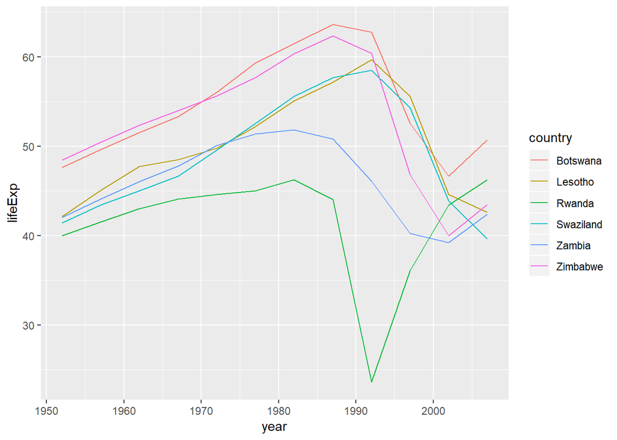

```r
gapminder %>%
  semi_join(bad_fit,by="country") %>%
  ggplot(aes(year,lifeExp,colour=country))+
  geom_line()
```

We see two main effects here: the tragedies of the HIV/AIDS epidemic and the Rwandan genocide.

### 25.2.5 Exercises

1. A linear trend seems to be slightly too simple for the overall trend. Can you do better with a quadratic polynomial? How can you interpret the coefficients of the quadratic? (Hint you might want to transform `year` so that it has mean zero.)
2. Explore other methods for visualising the distribution of  
   $R^2$ per continent. You might want to try the ggbeeswarm package, which provides similar methods for avoiding overlaps as jitter, but uses deterministic methods.
3. To create the last plot (showing the data for the countries with the worst model fits), we needed two steps: we created a data frame with one row per country and then semi-joined it to the original dataset. It’s possible to avoid this join if we use `unnest()` instead of `unnest(.drop = TRUE)`. How?

## 25.3 List-columns

Now that you’ve seen a basic workflow for managing many models, let’s dive back into some of the details. In this section, we’ll explore the list-column data structure in a little more detail. It’s only recently that I’ve really appreciated the idea of the list-column. List-columns are implicit in the definition of the data frame: a data frame is a named list of equal length vectors. A list is a vector, so it’s always been legitimate to use a list as a column of a data frame. However, base R doesn’t make it easy to create list-columns, and `data.frame()` treats a list as a list of columns:.

```r
data.frame(x=list(1:3,3:5))
```

```
##   x.1.3 x.3.5
## 1     1     3
## 2     2     4
## 3     3     5
```

You can prevent `data.frame()` from doing this with `I()`, but the results doesn’t print particulrly well:

```r
data.frame(
  x = I(list(1:3, 3:5)),
  y = c("1, 2", "3, 4, 5")
)
```

```
##         x       y
## 1 1, 2, 3    1, 2
## 2 3, 4, 5 3, 4, 5
```

```
#>         x       y
#> 1 1, 2, 3    1, 2
#> 2 3, 4, 5 3, 4, 5
```

Tibble alleviates this problem by being lazier (`tibble()`doesn’t modify its inpus) and by providing a better print method:

```r
tibble(
  x=list(1:3,3:5),
  y=c("1,2","3,4,5")
)
```

```
## # A tibble: 2 x 2
##   x         y
##   <list>    <chr>
## 1 <int [3]> 1,2
## 2 <int [3]> 3,4,5
```

[output not shown]

It’s even easier with `tribble()` as it can automatically work out that you need a list:

```r
trible <- tribble(
  ~x,~y,
  1:3,"1.2",
  3:5,"3,4,5"
)
trible$x[[1]]
```

```
## [1] 1 2 3
```

List-columns are often most useful as intermediate data structure. They’re hard to work with directly, because most R functions work with atomic vectors or data frames, but the advantage of keeping related items together in a data frame is worth a little hassle.

Generally, there are three parts of an effective list-column pipeline: 1. You create the list-column using one of `nest()`, `summarise()`+`list()` or `mutate()` + a map function, as described in Creating list-columns. 2. You create other intermediate list-columns by transforming existing list columns with `map()`, `map2()` or `pmap()`. For example, in the case study above, we created a list-column of models by transforming a list-column of data frames. 3. You simplify the list-column back down to a data frame or atomic vector, as described in Simplifying list-columns.

## 25.4 Creating list-columns

Typically, you won’t create list-columns with `tibble()`. Instead, you’ll create them from regular columns, using one of three methods.

1. With `tidyr::nest()` to convert a grouped data frame into a nested data frame where you have list-column of data frames.
2. With `mutate()` and vectorised functions that return a list.
3. With `summarise()` and summary functions that return multiple results.

Alternatively, you might create them from a named list, using `tibble::enframe()`.

Generally, when creating list-columns, you should make sure they’re homogeneous: each element should contain the same type of thing. There are no checks to make sure this is true, but if you use purrr and remember what you’ve learned about type-stable functions, you should find it happens naturally.

### 25.4.1 With nesting

`nest()` creates a nested data frame, which is a data frame with a list-column of data frames.In a nested data frame each row is a meta-observation: the other columns give variables that define the observation (like country and continent above), and the list-column of data frames gives the individual observations that make up the meta-observation.

```r
gapminder %>%
  group_by(country,continent) %>%
  nest()
```

```
## # A tibble: 142 x 3
##    country     continent data
##    <fct>       <fct>     <list>
##  1 Afghanistan Asia      <tibble [12 x 4]>
##  2 Albania     Europe    <tibble [12 x 4]>
##  3 Algeria     Africa    <tibble [12 x 4]>
##  4 Angola      Africa    <tibble [12 x 4]>
##  5 Argentina   Americas  <tibble [12 x 4]>
##  6 Australia   Oceania   <tibble [12 x 4]>
##  7 Austria     Europe    <tibble [12 x 4]>
##  8 Bahrain     Asia      <tibble [12 x 4]>
##  9 Bangladesh  Asia      <tibble [12 x 4]>
## 10 Belgium     Europe    <tibble [12 x 4]>
## # ... with 132 more rows
```

You can also use it on an ungrouped data frame, specifying which columns you want to nest:

```r
gapminder %>%
  names()
```

```
## [1] "country"   "continent" "year"      "lifeExp"   "pop"       "gdpPercap"
```

```r
gapminder %>%
  nest(year:gdpPercap)
```

```
## # A tibble: 142 x 3
##    country     continent data
##    <fct>       <fct>     <list>
##  1 Afghanistan Asia      <tibble [12 x 4]>
##  2 Albania     Europe    <tibble [12 x 4]>
##  3 Algeria     Africa    <tibble [12 x 4]>
##  4 Angola      Africa    <tibble [12 x 4]>
##  5 Argentina   Americas  <tibble [12 x 4]>
##  6 Australia   Oceania   <tibble [12 x 4]>
##  7 Austria     Europe    <tibble [12 x 4]>
##  8 Bahrain     Asia      <tibble [12 x 4]>
##  9 Bangladesh  Asia      <tibble [12 x 4]>
## 10 Belgium     Europe    <tibble [12 x 4]>
## # ... with 132 more rows
```

### 25.4.2 From vectorised functions

Some useful functions take an atomic vector and return a list. For example, in strings you learned about `stringr::str_split()` which takes a character vector and returns a list of character vectors. If you use that inside mutate, you’ll get a list-column:

```r
df <- tribble(
  ~x1,
  "a,b,c",
  "d,e,f,g"
)

df %>%
  mutate(x2=stringr::str_split(x1,","))
```

```
## # A tibble: 2 x 2
##   x1      x2
##   <chr>   <list>
## 1 a,b,c   <chr [3]>
## 2 d,e,f,g <chr [4]>
```

`unnest()` knows how to handle these lists of vectors:

```r
df %>%
  mutate(x2=stringr::str_split(x1,",")) %>%
  unnest()
```

```
## # A tibble: 7 x 2
##   x1      x2
##   <chr>   <chr>
## 1 a,b,c   a
## 2 a,b,c   b
## 3 a,b,c   c
## 4 d,e,f,g d
## 5 d,e,f,g e
## 6 d,e,f,g f
## 7 d,e,f,g g
```

(If you find yourself using this pattern a lot, make sure to check out `tidyr::separate_rows()` which is a wrapper around this common pattern).

Another example of this pattern is using the `map()`, `map2()`, `pmap()` from purrr. For example, we could take the final example from Invoking different functions and rewrite it to use `mutate():`

```r
sim <- tribble(
  ~f,      ~params,
  "runif", list(min = -1, max = 1),
  "rnorm", list(sd = 5),
  "rpois", list(lambda = 10)
)

sim %>%
  mutate(sims = invoke_map(f, params, n = 10))
```

```
## # A tibble: 3 x 3
##   f     params     sims
##   <chr> <list>     <list>
## 1 runif <list [2]> <dbl [10]>
## 2 rnorm <list [1]> <dbl [10]>
## 3 rpois <list [1]> <int [10]>
```

Note that technically `sim` isn’t homogeneous because it contains both double and integer vectors. However, this is unlikely to cause many problems since integers and doubles are both numeric vectors.

### 25.4.3 From multivalued summaries

One restriction of `summarise()` is that it only works with summary functions that return a single value. That means that you can’t use it with functions like `quantile()` that return a vector of arbitrary length:

```r
mtcars %>%
  group_by(cyl) %>%
  summarise(q=quantile(mpg))
```

```
#> Error in summarise_impl(.data, dots): Column `q` must be length 1 (a summary value), not 5
```

You can, however, wrap the results in a list! This obeys the contract of `summarise()`, because each summary is now a list (a vector) of length 1.

```r
mtcars1 <- mtcars %>%
  group_by(cyl) %>%
  summarise(q=list(quantile(mpg)))

mtcars1
```

```
## # A tibble: 3 x 2
##     cyl q
##   <dbl> <list>
## 1     4 <dbl [5]>
## 2     6 <dbl [5]>
## 3     8 <dbl [5]>
```

```r
mtcars1$q[[1]]
```

```
##   0%  25%  50%  75% 100%
## 21.4 22.8 26.0 30.4 33.9
```

To make useful results with **unnest**, you’ll also need to capture the probabilities:

```r
probs <- c(0.01,0.25,0.5,0.75,0.99)
mtcars %>%
  group_by(cyl) %>%
  summarise(p=list(probs),q=list(quantile(mpg,probs))) %>%
  unnest()
```

```
## # A tibble: 15 x 3
##      cyl     p     q
##    <dbl> <dbl> <dbl>
##  1     4  0.01  21.4
##  2     4  0.25  22.8
##  3     4  0.5   26
##  4     4  0.75  30.4
##  5     4  0.99  33.8
##  6     6  0.01  17.8
##  7     6  0.25  18.6
##  8     6  0.5   19.7
##  9     6  0.75  21
## 10     6  0.99  21.4
## 11     8  0.01  10.4
## 12     8  0.25  14.4
## 13     8  0.5   15.2
## 14     8  0.75  16.2
## 15     8  0.99  19.1
```

```r
  # filter(cyl==4)
```

### 25.4.4 From a named list

Data frames with list-columns provide a solution to a common problem: what do you do if you want to iterate over both the contents of a list and its elements? Instead of trying to jam everything into one object, it’s often easier to make a data frame: one column can contain the elements, and one column can contain the list. An easy way to create such a data frame from a list is `tibble::enframe()`.

```r
x <- list(
  a=1:5,
  b=3:4,
  c=5:6
)

df <- enframe(x)
df
```

```
## # A tibble: 3 x 2
##   name  value
##   <chr> <list>
## 1 a     <int [5]>
## 2 b     <int [2]>
## 3 c     <int [2]>
```

The advantage of this structure is that it generalises in a straightforward way - names are useful if you have character vector of metadata, but don’t help if you have other types of data, or multiple vectors.

Now if you want to iterate over names and values in parallel, you can use `map2()`:

```r
df %>%
  mutate(
    smry = map2_chr(name, value, ~ stringr::str_c(.x, ": ", .y[1]))
  )
```

```
## # A tibble: 3 x 3
##   name  value     smry
##   <chr> <list>    <chr>
## 1 a     <int [5]> a: 1
## 2 b     <int [2]> b: 3
## 3 c     <int [2]> c: 5
```

### 25.4.5 Exercises

```r
mtcars %>%
  group_by(cyl) %>%
  summarise_each(funs(list))
```

```
## `summarise_each()` is deprecated.
## Use `summarise_all()`, `summarise_at()` or `summarise_if()` instead.
## To map `funs` over all variables, use `summarise_all()`
```

```
## # A tibble: 3 x 11
##     cyl mpg    disp   hp     drat   wt     qsec   vs     am    gear  carb
##   <dbl> <list> <list> <list> <list> <list> <list> <list> <lis> <lis> <lis>
## 1     4 <dbl ~ <dbl ~ <dbl ~ <dbl ~ <dbl ~ <dbl ~ <dbl ~ <dbl~ <dbl~ <dbl~
## 2     6 <dbl ~ <dbl ~ <dbl ~ <dbl ~ <dbl ~ <dbl ~ <dbl ~ <dbl~ <dbl~ <dbl~
## 3     8 <dbl ~ <dbl ~ <dbl ~ <dbl ~ <dbl ~ <dbl ~ <dbl ~ <dbl~ <dbl~ <dbl~
```

## 25.5 Simplifying list-columns

To apply the techniques of data manipulation and visualisation you’ve learned in this book, you’ll need to simplify the list-column back to a regular column (an atomic vector), or set of columns. The technique you’ll use to collapse back down to a simpler structure depends on whether you want a single value per element, or multiple values:

1. If you want a single value, use `mutate()` with `map_lgl()`, `map_int()`, `map_dbl()`, and `map_chr()` to create an atomic vector.
2. If you want many values, use `unnest()` to convert list-columns back to regular columns, repeating the rows as many times as necessary.

These are described in more detail below.

### 25.5.1 List to vector

If you can reduce your list column to an atomic vector then it will be a regular column. For example, you can always summarise an object with its type and length, so this code will work regardless of what sort of list-column you have:

```r
df <- tribble(
  ~x,
  letters[1:5],
  1:3,
  runif(5)
)

df %>%
  mutate(
    type=map_chr(x,typeof),
    length=map_int(x,length)
  )
```

```
## # A tibble: 3 x 3
##   x         type      length
##   <list>    <chr>      <int>
## 1 <chr [5]> character      5
## 2 <int [3]> integer        3
## 3 <dbl [5]> double         5
```

This is the same basic information that you get from the default tbl print method, but now you can use it for filtering. This is a useful technique if you have a heterogeneous list, and want to filter out the parts aren’t working for you.

Don’t forget about the `map_*()` shortcuts - you can use `map_chr(x, "apple")` to extract the string stored in apple for each element of `x`. This is useful for pulling apart nested lists into regular columns. Use the `.null` argument to provide a value to use if the element is missing (instead of returning `NULL`):

```r
library(tidyverse)

df <- tribble(
  ~x,
  list(a=1,b=2),
  list(a=2,c=4)
)
df
```

```
## # A tibble: 2 x 1
##   x
##   <list>
## 1 <list [2]>
## 2 <list [2]>
```

```r
df %>%
  mutate(
    a=map_dbl(x,"a"),
    b=map_dbl(x,"b",.null=NA_real_)
  )
```

```
## # A tibble: 2 x 3
##   x              a     b
##   <list>     <dbl> <dbl>
## 1 <list [2]>     1     2
## 2 <list [2]>     2    NA
```

### 25.5.2 Unnesting

`unnest()` works by repeating the regular columns once for each element of the list-column. For example, in the following very simple example, we repeat the first row 4 times (because there the first element of `y` has length four). and the second row once:

```r
tibble(x=1:2,y=list(1:4,1))
```

```
## # A tibble: 2 x 2
##       x y
##   <int> <list>
## 1     1 <int [4]>
## 2     2 <dbl [1]>
```

```r
tibble(x=1:2,y=list(1:4,1)) %>%
  unnest(y)
```

```
## # A tibble: 5 x 2
##       x     y
##   <int> <dbl>
## 1     1     1
## 2     1     2
## 3     1     3
## 4     1     4
## 5     2     1
```

This means you can’t simutaneously unnest two columns that contain different number of elements:

```r
df1 <- tribble(
  ~x,~y,~z,
  1,c("a","b"),1:2,
  2,"c",3
)

df1
```

```
## # A tibble: 2 x 3
##       x y         z
##   <dbl> <list>    <list>
## 1     1 <chr [2]> <int [2]>
## 2     2 <chr [1]> <dbl [1]>
```

```r
df1 %>% unnest(y,z)
```

```
## # A tibble: 3 x 3
##       x y         z
##   <dbl> <chr> <dbl>
## 1     1 a         1
## 2     1 b         2
## 3     2 c         3
```

```r
# doesn't work because y and z have different number of elements
df2 <- tribble(
  ~x,~y,~z,
  1,"a",1:2,
  2,c("b","c"),3
)

df2
df2 %>% unnest(y,z)
```

```
#> Error: All nested columns must have the same number of elements.
```

The same principle applies when unnesting list-columns of data frames. You can unnest multiple list-cols as long as all the data frames in each row have the same number of rows.

## 25.6 Making tidy data with broom

The broom package provides three general tools for turning models into tidy data frames:

1. `broom::glance(model)` returns a row for each model. Each column gives a model summary: either a measure of model quality, or complexity, or a combination of the two.
2. `broom::tidy(model)` returns a row for each coefficient in the model. Each column gives information about the estimate or its variability.
3. `broom::augment(model, data)` returns a row for each row in data, adding extra values like residuals, and influence statistics.